# Model annuel

2023-09-01

# Annual data

### On se propose de simuler et de prédire le bilan annuel suivant:

|  | 2022 | 2021 | 2020 | 2019 | 2018 | 2017 | 2016 | 2015 |
| --- | --- | --- | --- | --- | --- | --- | --- | --- |
| AC1: Caisse et avoirs auprès de la BCT, CCP et TGT | 445813 | 169241 | 425311 | 788319 | 402287 | 170245 | 107721 | 107781 |
| AC2: Créances sur les établissements bancaires et financiers | 142141 | 360094 | 232659 | 241527 | 183294 | 197032 | 169829 | 193873 |
| AC3: Créances sur la clientèle | 6889784 | 6245664 | 6003059 | 5727900 | 5929248 | 6073730 | 5893685 | 5971463 |
| AC4: Portefeuille-titres commercial | 72286 | 94308 | 135191 | 257741 | 285622 | 530671 | 599200 | 905996 |
| AC5: Portefeuille d’investissement | 2296013 | 2176090 | 1979064 | 1536997 | 1612371 | 1361537 | 1193230 | 570774 |
| AC6: Valeurs immobilisées | 397473 | 270250 | 208163 | 188436 | 166778 | 163219 | 120854 | 117566 |
| AC7: Autres actifs | 163260 | 227763 | 194124 | 210993 | 233528 | 159764 | 158398 | 72601 |
| Total actifs | 10406770 | 9543410 | 9177571 | 8951913 | 8813128 | 8656198 | 8242917 | 7940054 |
| PA1: Banque Centrale et CCP | 815324 | 595871 | 764816 | 1066677 | 1072065 | 1174816 | 818196 | 500194 |
| PA2: Dépôts et avoirs des établissements bancaires et financiers | 242370 | 258589 | 259044 | 232846 | 235057 | 385115 | 468866 | 509230 |
| PA3: Dépôts et avoirs de la clientèle | 6990819 | 6343825 | 5861002 | 5559635 | 5516889 | 5137206 | 5116938 | 5142391 |
| PA4: Emprunts et Ressources spéciales | 825551 | 926283 | 968332 | 875676 | 876255 | 968065 | 914432 | 911881 |
| PA5: Autres passifs | 230533 | 232599 | 210426 | 202531 | 207581 | 172039 | 190154 | 205186 |
| Total passifs | 9104597 | 8357167 | 8063620 | 7937365 | 7907847 | 7837241 | 7508586 | 7268882 |
| CP1: Capital | 132405 | 132405 | 132405 | 132405 | 132405 | 132405 | 127313 | 122220 |
| CP2: Réserves | 1014465 | 923755 | 844373 | 736529 | 652478 | 572213 | 516585 | 488066 |
| CP4: Autres capitaux propres | 423 | 423 | 423 | 423 | 423 | 423 | 423 | 423 |
| CP5: Résultats reportés | 1 | 5 | 37091 | 26 | 5 | 5 | 4 | 5 |
| CP6: Résultat de l’exercice | 154879 | 129655 | 99659 | 145165 | 119970 | 113911 | 90006 | 60458 |
| Total capitaux propres | 1302173 | 1186243 | 1113951 | 1014548 | 905281 | 818957 | 734331 | 671172 |
| Total capitaux propres et passifs | 10406770 | 9543410 | 9177571 | 8951913 | 8813128 | 8656198 | 8242917 | 7940054 |

#### On va procéder à la modélisation des variables du blian en se basant sur les techniques des séries temporelles.

- La variable AC1 représente un cliché “snapshot” des espèces et équivalents de trésorerie de la banque auprès des institutions financières, il s’agit donc d’une variable qui ne suit pas une tendance bien déterminée puisque sa valeur est enregistrée au hasard.
- La variable AC2 représente les créances sur les établissements bancaires et financiers. Il s’agit d’une variable très volatile du fait de l’abondance des transactions entres les institutions financières.
- Il convient donc de combiner ses deux variables en une variables **AC12** qui contient leur somme.

## AC12

##### Visualisation

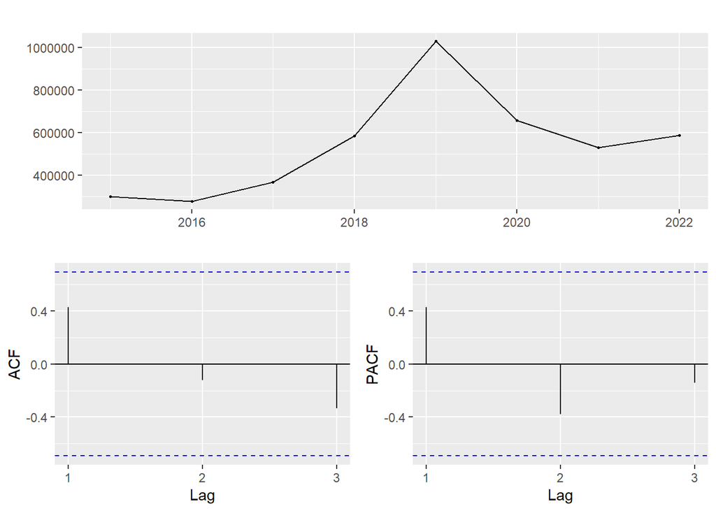

```r
#####visualisation
ts.ac12<-ts(rev(b$ac1+b$ac2),start=2015,frequency=1)
ggtsdisplay(ts.ac12)
```

```r
#plot(decompose(ts.ac12))
```

##### Preprocessing/heteroskedasticity_test

```r
BoxCox.lambda(ts.ac12)
```

```
## [1] -0.914
```

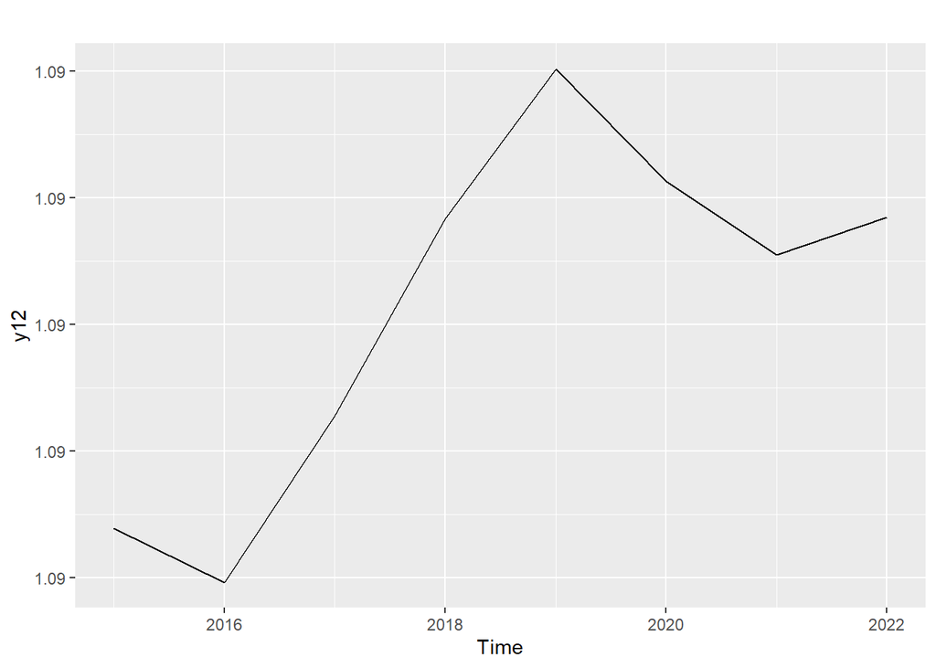

```r
y12<-BoxCox(ts.ac12,lambda = BoxCox.lambda(ts.ac12)) #bxcx(y, lambda, InverseQ=TRUE)
autoplot(y12)
```

#### ETS

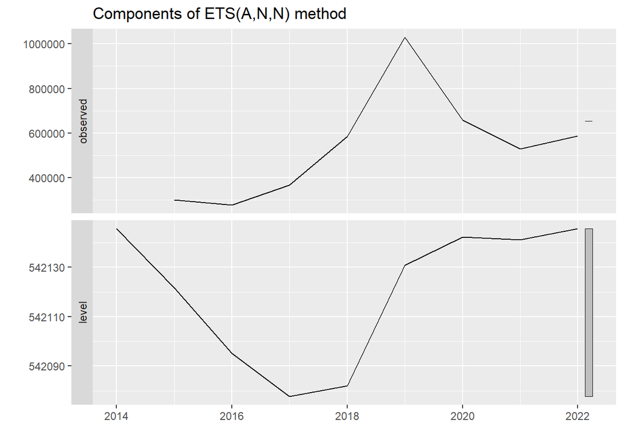

```r
fit12.ets<-ets(ts.ac12)
autoplot(fit12.ets)
```

```r
summary(fit12.ets)
```

```
## ETS(A,N,N)
##
## Call:
##  ets(y = ts.ac12)
##
##   Smoothing parameters:
##     alpha = 0.0001
##
##   Initial states:
##     l = 542145.636
##
##   sigma:  262642
##
##  AIC AICc  BIC
##  220  226  220
##
## Training set error measures:
##                ME   RMSE    MAE   MPE MAPE  MASE ACF1
## Training set 28.9 227454 173201 -18.1 38.2 0.908 0.43
```

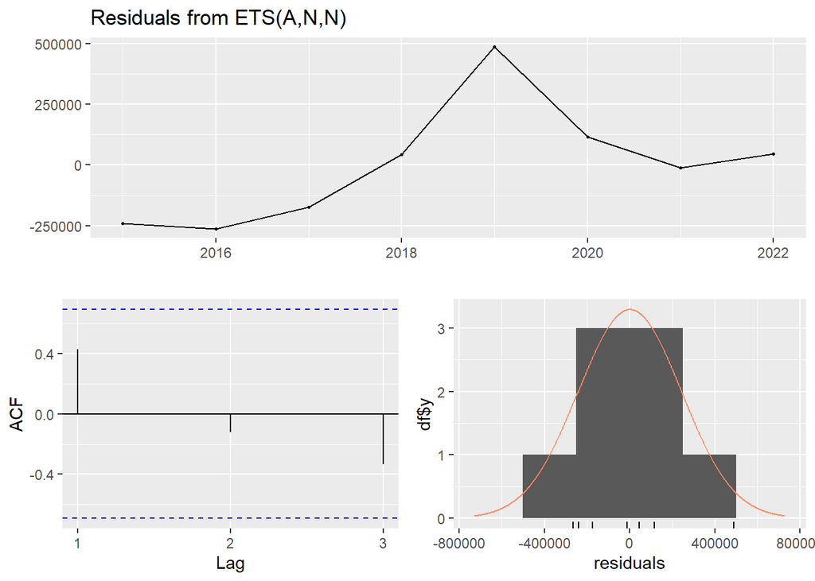

```
##
##  Ljung-Box test
##
## data:  Residuals from ETS(A,N,N)
## Q* = 4, df = 3, p-value = 0.3
##
## Model df: 0.   Total lags used: 3
```

```r
checkresiduals(fit12.ets)
```

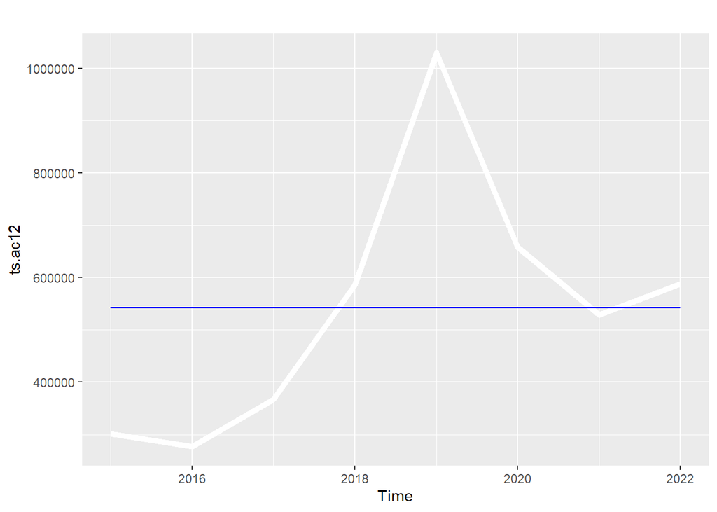

```r
autoplot(ts.ac12, color = "white", lwd = 2) +
   autolayer(fit12.ets$fitted, color = "blue")
```

```r
forecast.ets(fit12.ets)
```

```
##      Point Forecast  Lo 80  Hi 80 Lo 95   Hi 95
## 2023         542146 205557 878734 27378 1056914
## 2024         542146 205557 878734 27378 1056914
## 2025         542146 205557 878734 27378 1056914
## 2026         542146 205557 878734 27378 1056914
## 2027         542146 205557 878734 27378 1056914
## 2028         542146 205557 878734 27378 1056914
## 2029         542146 205557 878734 27378 1056914
## 2030         542146 205557 878734 27378 1056914
## 2031         542146 205557 878734 27378 1056914
## 2032         542146 205557 878734 27378 1056914
```

```r
#ggtsdisplay(fit12.ets$residuals)
#flat prediction
```

#### HOLT (ses will give flat prediction/Holt-Winters not applicable_no_periodicity)

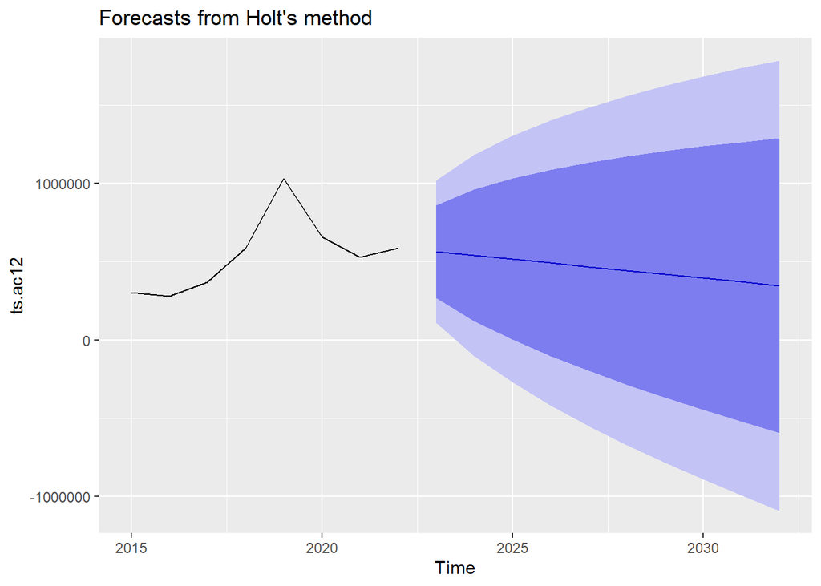

```r
fit12.holt<-holt(ts.ac12)
# with or without dumping almost the same
# forecast(fit12.holt)
autoplot(fit12.holt)
```

```r
summary(fit12.holt)
```

```
##
## Forecast method: Holt's method
##
## Model Information:
## Holt's method
##
## Call:
##  holt(y = ts.ac12)
##
##   Smoothing parameters:
##     alpha = 1
##     beta  = 0
##
##   Initial states:
##     l = 301654
##     b = -24104
##
##   sigma:  231944
## Error measures:
##                 ME   RMSE    MAE  MPE MAPE  MASE    ACF1
## Training set 59892 231944 172967 8.42 26.6 0.907 -0.0496
##
## Forecasts:
##      Point Forecast   Lo 80   Hi 80    Lo 95   Hi 95
## 2023         563850  266602  861098   109248 1018452
## 2024         539746  119373  960119  -103159 1182651
## 2025         515642     793 1030491  -271752 1303036
## 2026         491538 -102959 1086035  -417667 1400743
## 2027         467434 -197234 1132102  -549088 1483956
## 2028         443330 -284777 1171437  -670214 1556874
## 2029         419226 -367219 1205671  -783539 1621991
## 2030         395122 -445624 1235868  -890687 1680931
## 2031         371018 -520727 1262763  -992789 1734825
## 2032         346914 -593068 1286896 -1090665 1784493
```

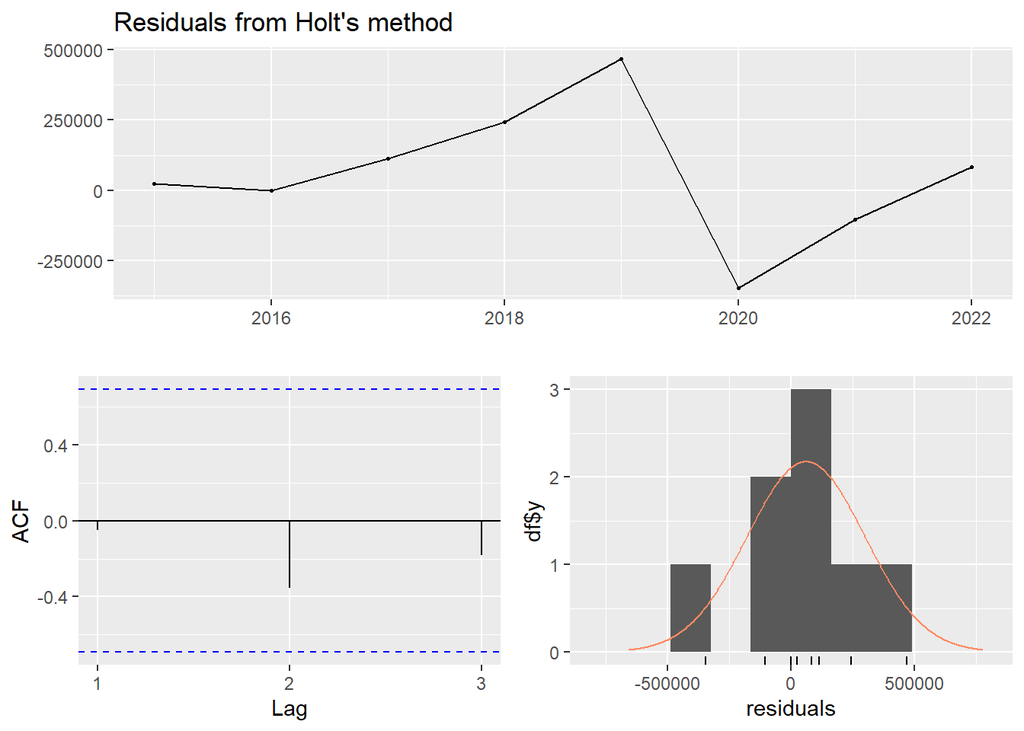

```
##
##  Ljung-Box test
##
## data:  Residuals from Holt's method
## Q* = 2, df = 3, p-value = 0.5
##
## Model df: 0.   Total lags used: 3
```

```r
checkresiduals(fit12.holt)
```

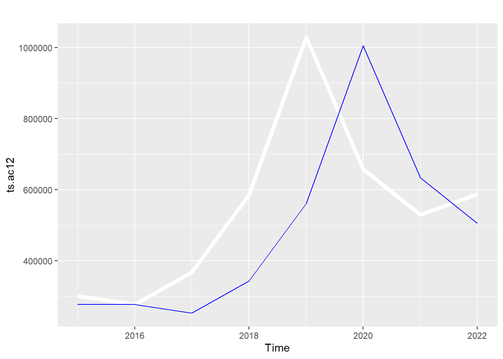

```r
autoplot(ts.ac12, color = "white", lwd = 2) +
   autolayer(fit12.holt$fitted, color = "blue")
```

####ARIMA

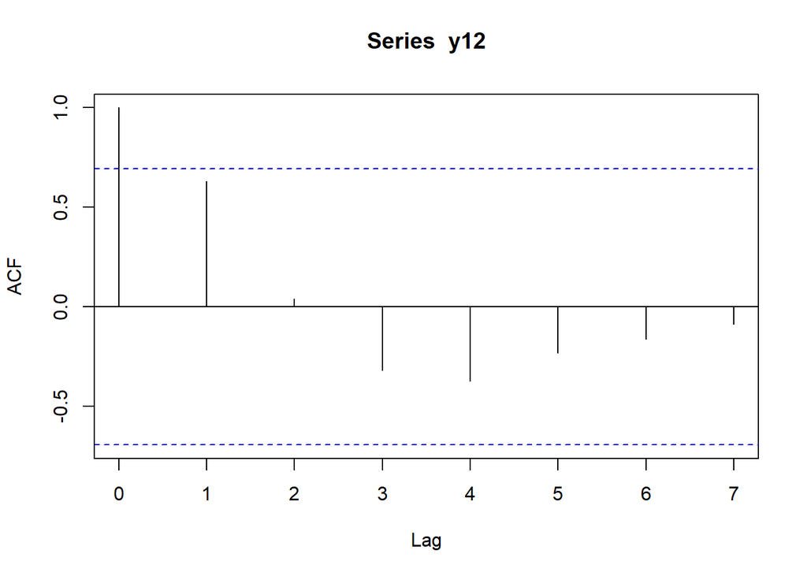

```r
acf(y12)
```

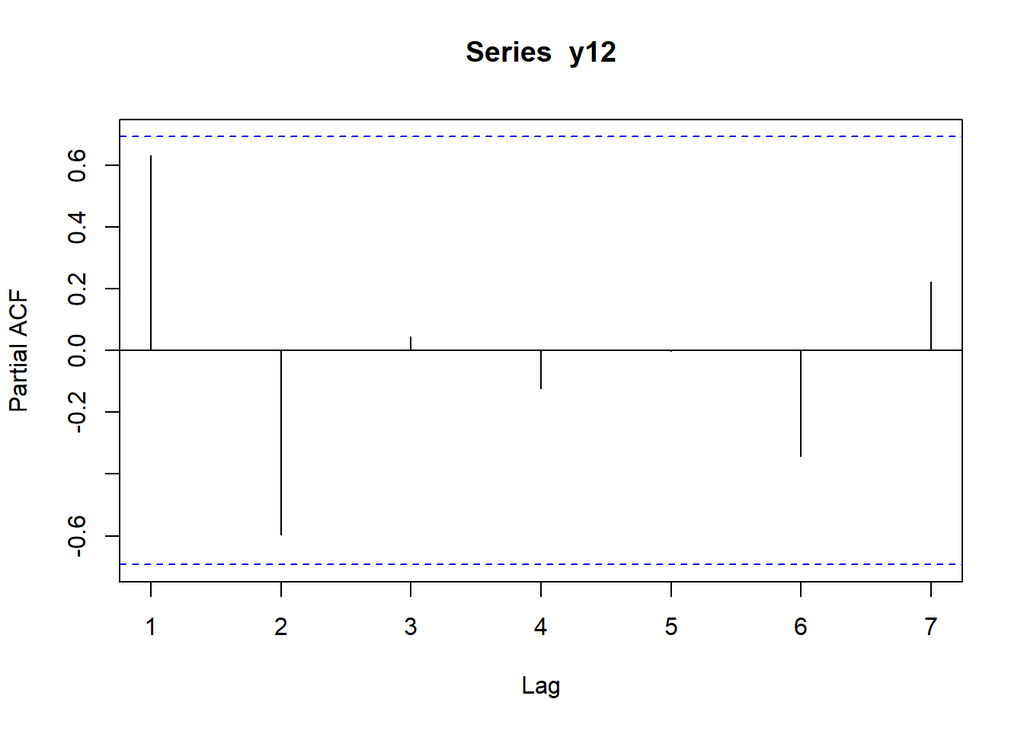

```r
pacf(y12)
```

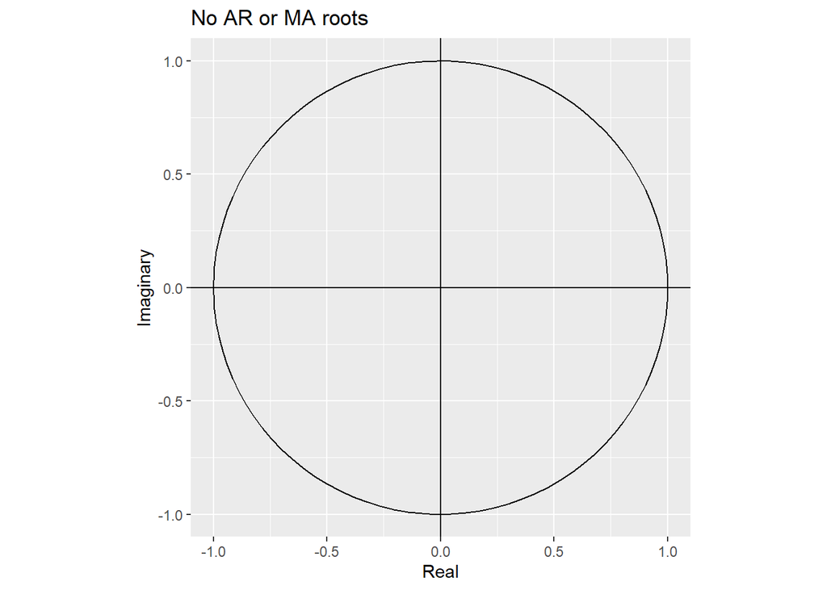

```r
fit12.arima<-auto.arima(y12)
autoplot(fit12.arima)
```

```r
summary(fit12.arima)
```

```
## Series: y12
## ARIMA(0,1,0)
##
## sigma^2 = 0.000000171:  log likelihood = 82
## AIC=-162   AICc=-161   BIC=-162
##
## Training set error measures:
##                    ME     RMSE      MAE    MPE   MAPE MASE    ACF1
## Training set 0.000137 0.000387 0.000138 0.0126 0.0126 77.6 -0.0195
```

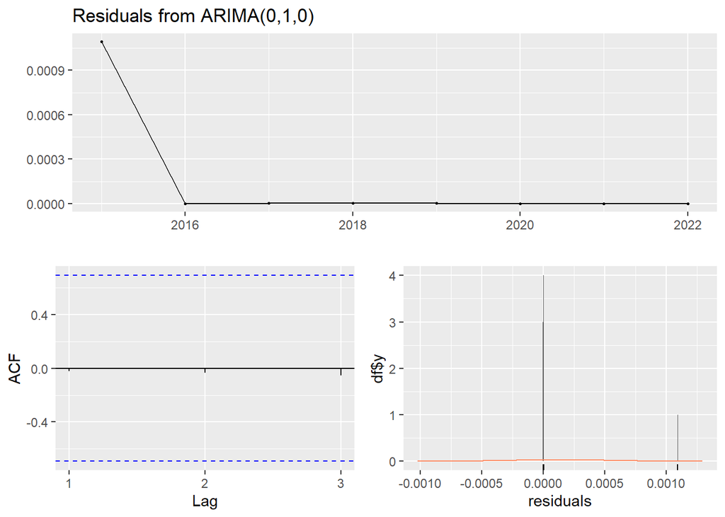

```
##
##  Ljung-Box test
##
## data:  Residuals from ARIMA(0,1,0)
## Q* = 0.06, df = 3, p-value = 1
##
## Model df: 0.   Total lags used: 3
```

```r
checkresiduals(fit12.arima)
```

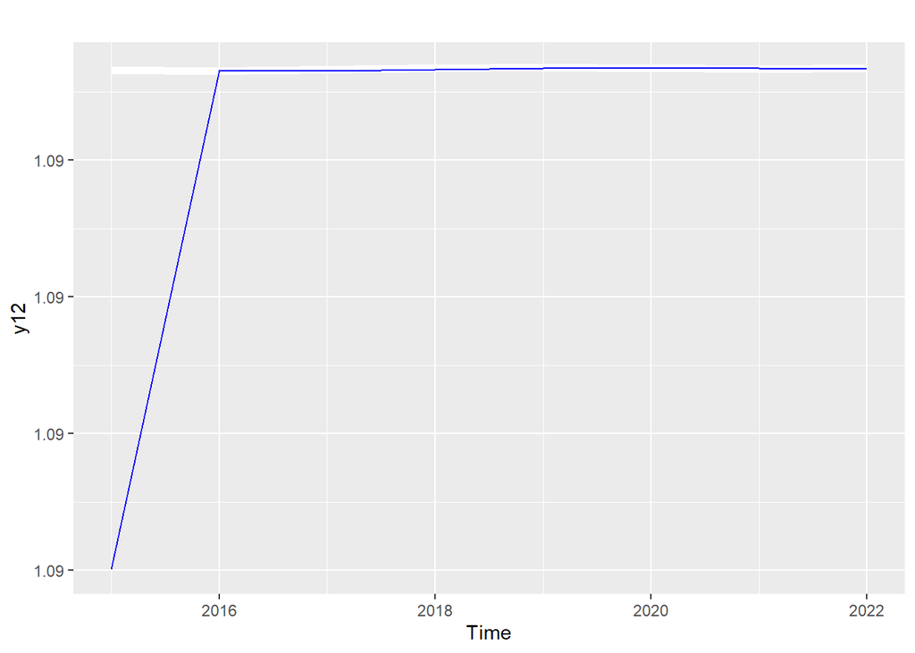

```r
autoplot(y12, color = "white", lwd = 2) +
   autolayer(fit12.arima$fitted, color = "blue")
```

#### TBATS

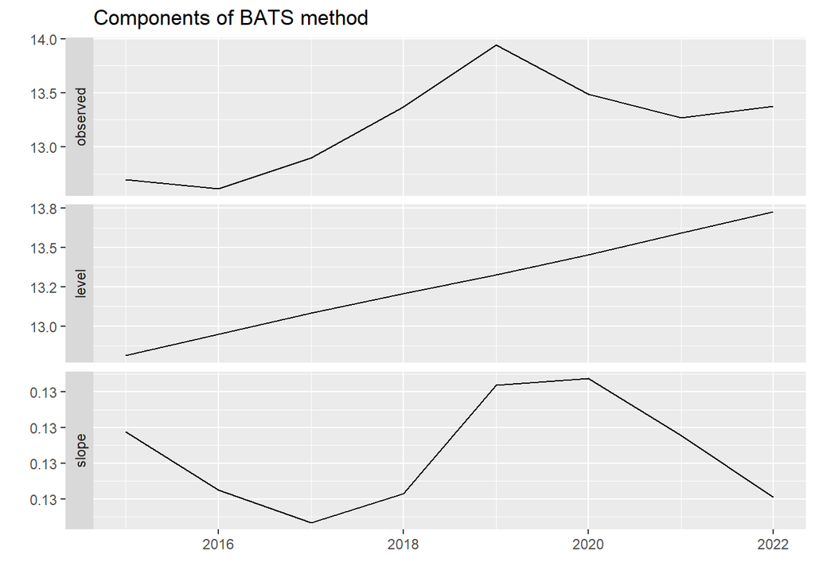

```r
fit12.TBATS<-tbats(ts.ac12)
autoplot(fit12.TBATS)
```

```r
summary(fit12.TBATS)
```

```
##                   Length Class  Mode
## lambda             1     -none- numeric
## alpha              1     -none- numeric
## beta               1     -none- numeric
## damping.parameter  1     -none- numeric
## gamma.values       0     -none- NULL
## ar.coefficients    0     -none- NULL
## ma.coefficients    0     -none- NULL
## likelihood         1     -none- numeric
## optim.return.code  1     -none- numeric
## variance           1     -none- numeric
## AIC                1     -none- numeric
## parameters         2     -none- list
## seed.states        2     -none- numeric
## fitted.values      8     ts     numeric
## errors             8     ts     numeric
## x                 16     -none- numeric
## seasonal.periods   0     -none- NULL
## y                  8     ts     numeric
## call               2     -none- call
## series             1     -none- character
## method             1     -none- character
```

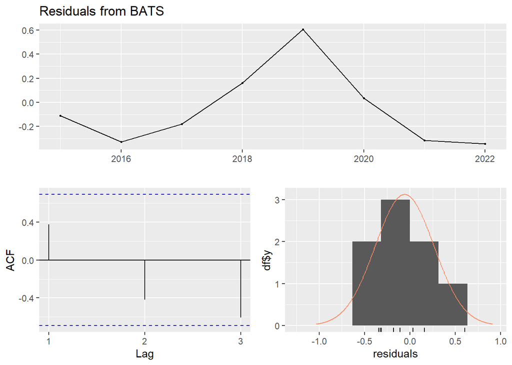

```
##
##  Ljung-Box test
##
## data:  Residuals from BATS
## Q* = 10, df = 3, p-value = 0.02
##
## Model df: 0.   Total lags used: 3
```

```r
checkresiduals(fit12.TBATS)
```

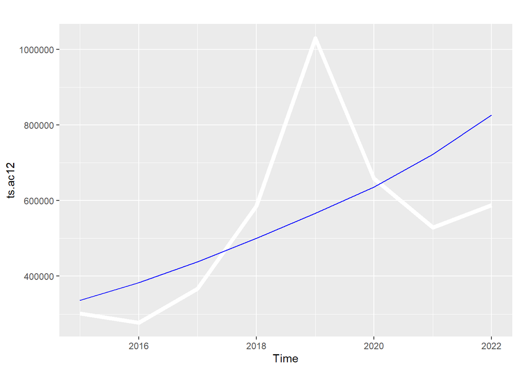

```r
autoplot(ts.ac12, color = "white", lwd = 2) +
   autolayer(fit12.TBATS$fitted, color = "blue")
```

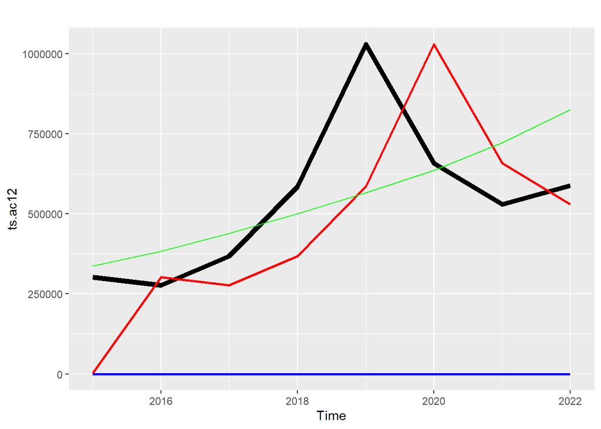

```r
#### Model comparison
autoplot(ts.ac12, color = "black", lwd = 2) +
  autolayer(bxcx(fit12.ets$fitted, lambda= BoxCox.lambda(ts.ac12) , InverseQ=TRUE), color = "blue", lwd = 1) +
  autolayer(bxcx(fit12.arima$fitted, lambda= BoxCox.lambda(ts.ac12), InverseQ=TRUE), color = "red", lwd = 1) +
  autolayer(fit12.TBATS$fitted.values, color = "green")
```

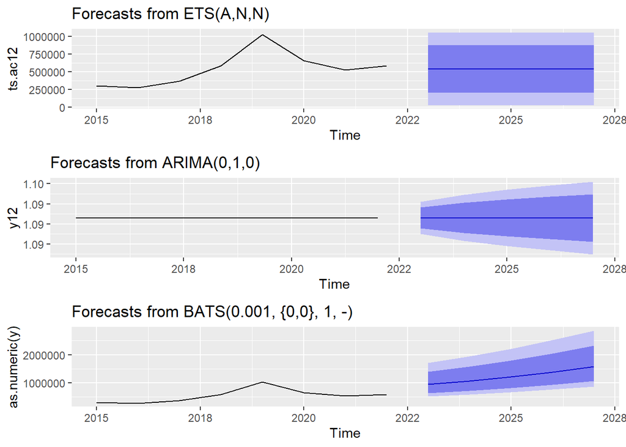

```r
grid.arrange(autoplot(forecast(fit12.ets,h=5)), autoplot(forecast(fit12.arima,h=5)), autoplot(forecast(fit12.TBATS,h=5)))
```

```r
f12.ets <- function (y,h) forecast(fit12.ets,h=h)
f12.holt <- function (y,h) forecast(fit12.holt,h=h)
f12.TBATS <- function (y,h) forecast(fit12.TBATS,h=h)

hmax<-5

e12.holt<-na.omit(tsCV(y12,f12.holt,h=hmax))[,hmax]
e12.ets<-na.omit(tsCV(y12,f12.ets,h=hmax))[,hmax]
# e12.TBATS<-na.omit(tsCV(ts.ac12,f12.TBATS,h=hmax))[,hmax]

summary(data.frame(e12.holt^2,e12.ets^2))
```

```
##    e12.holt.2             e12.ets.2
##  Min.   :218493521329   Min.   :293920729116
##  1st Qu.:218493521329   1st Qu.:293920729116
##  Median :218493521330   Median :293920729116
##  Mean   :218493521330   Mean   :293920729116
##  3rd Qu.:218493521330   3rd Qu.:293920729117
##  Max.   :218493521330   Max.   :293920729117
```

```r
#### On opte à priori pour la méthode de HOLT.
```

```r
#### Forecasting
forecast(fit12.holt)$mean
```

```
## Time Series:
## Start = 2023
## End = 2032
## Frequency = 1
##  [1] 563850 539746 515642 491538 467434 443330 419226 395122 371018 346914
```

```r
# ds <- window(forecast(fit12.holt)$mean, start=2023, end=2027)
# ds1<-as.vector(ds)

# bxcx(fit12.holt$mean, lambda=BoxCox.lambda(ts.ac12), InverseQ=TRUE)
# predict(fit12.holt, n.ahead=10)
```

## AC3: Créances sur la clientèle

##### Visualisation

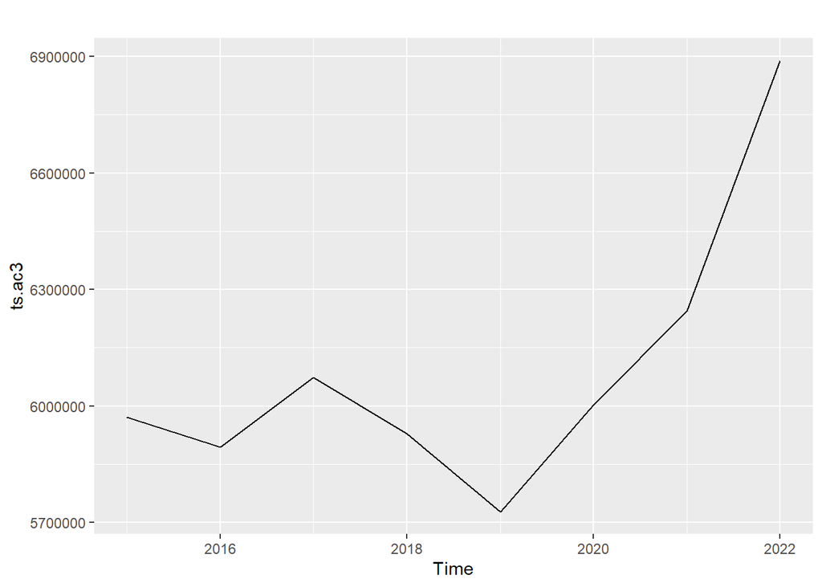

```r
#####visualisation
ts.ac3<-ts(rev(b$ac3),start=2015,frequency=1)
autoplot(ts.ac3)
```

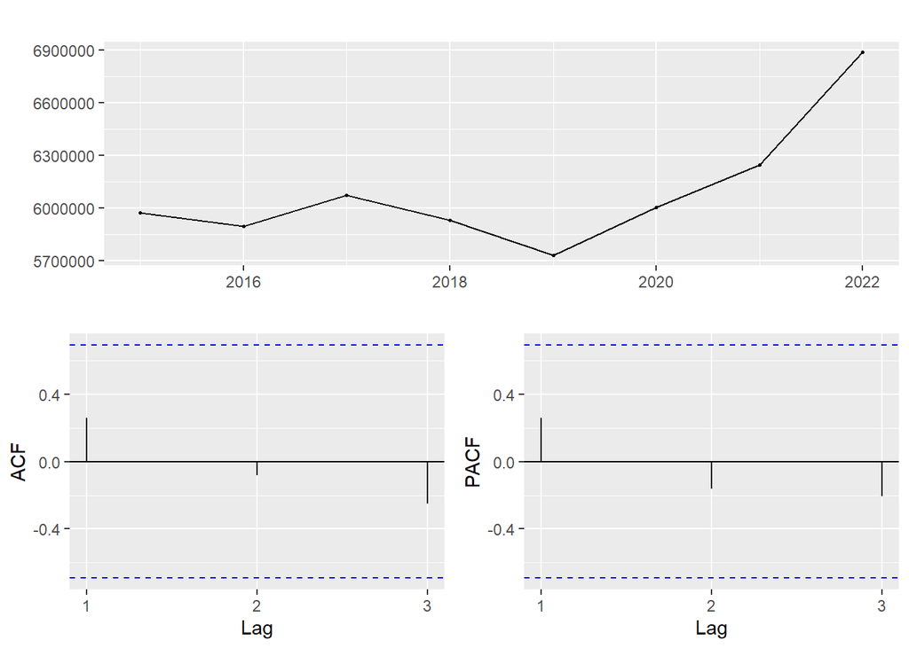

```r
ggtsdisplay(ts.ac3)
```

##### Preprocessing/heteroskedasticity_test

```r
BoxCox.lambda(ts.ac3)
```

```
## [1] -1
```

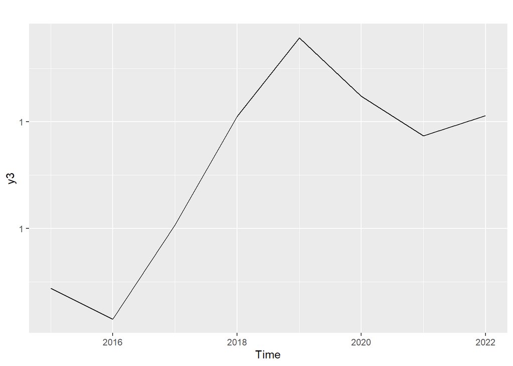

```r
y3<-BoxCox(ts.ac12,lambda = BoxCox.lambda(ts.ac3))
autoplot(y3)
```

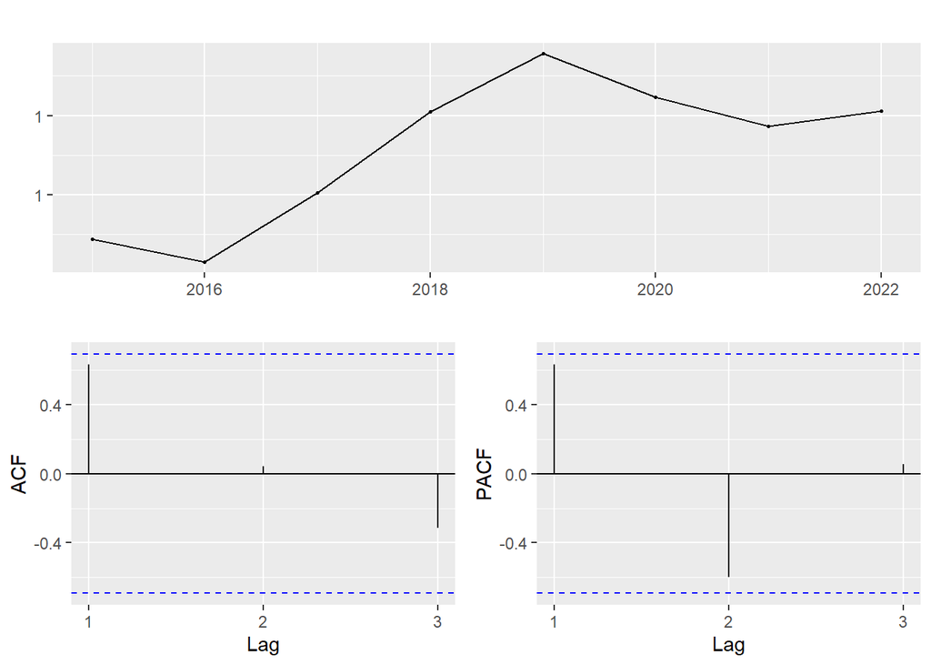

```r
ggtsdisplay(y3)
```

#### HOLT (no SES/HW)

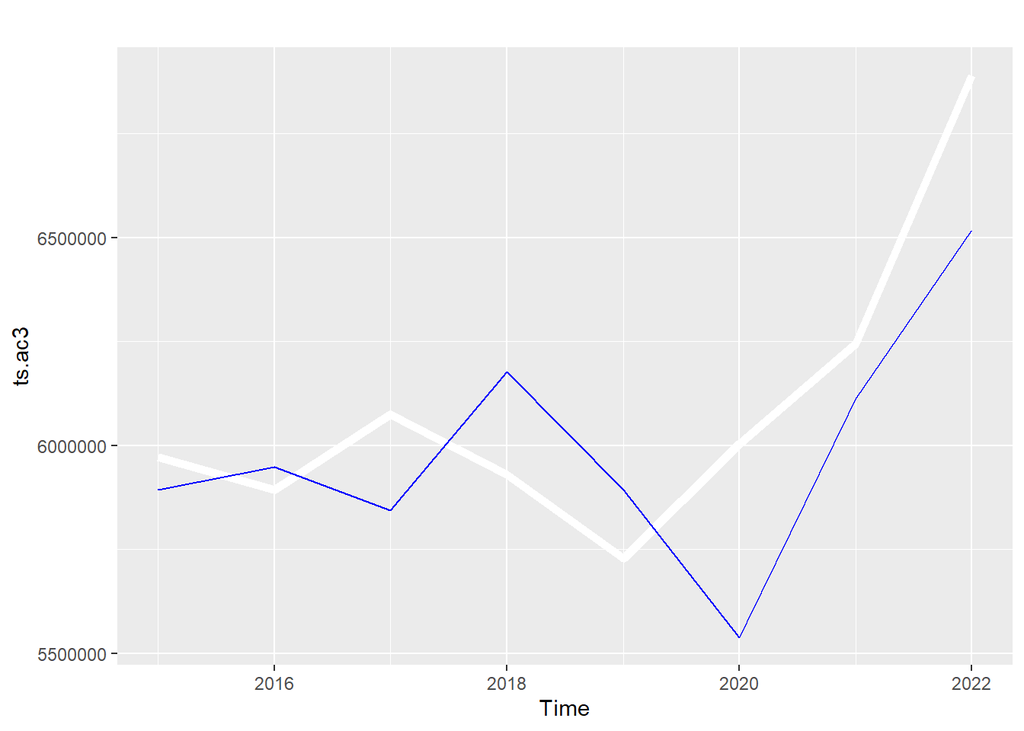

```r
# er<- function(p) {
#   alpha <- p[1]
#   beta <- p[2]
#   holt_fit <- holt(ts.ac3, alpha = alpha, beta = beta)
#   e<- mean((ts.ac3 - holt_fit$mean)^2)
#   return(e)
# }
# limites<- c(0, 1)
# p_init<- c(0.4, 0.4)
# opt<- optim(p_init, fn = er)
#
# opt<-bobyqa(p_init, fn = er, lower = limites[1], upper = limites[2])
fit3.holt<-holt(ts.ac3)
autoplot(ts.ac3, color = "white", lwd = 2) +
   autolayer(fit3.holt$fitted, color = "blue")
```

```r
# with or without dumping almost the same
# forecast(fit12.holt)
# autoplot(fit3.holt)
# summary(fit3.holt)
# checkresiduals(fit3.holt)
```

####ARIMA

AC3 Shows no seasonality and very little to unexisting correlation == arima not a suitable candidate.

#### TBATS

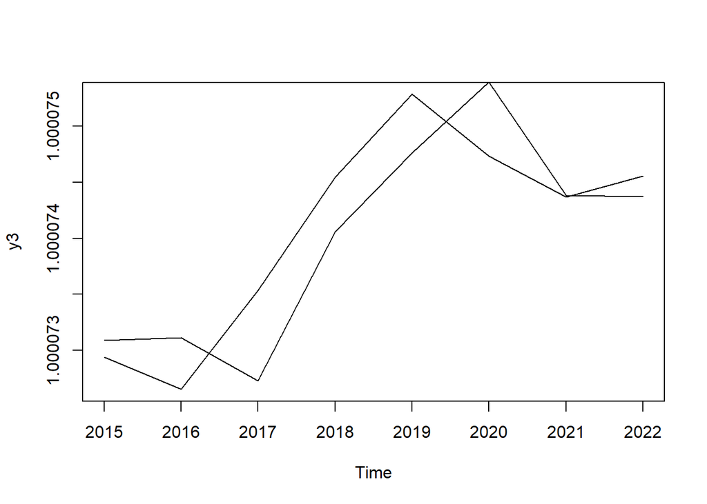

```r
fit3.TBATS<-tbats(y3)
plot(y3)
lines(fit3.TBATS$fitted.values)
```

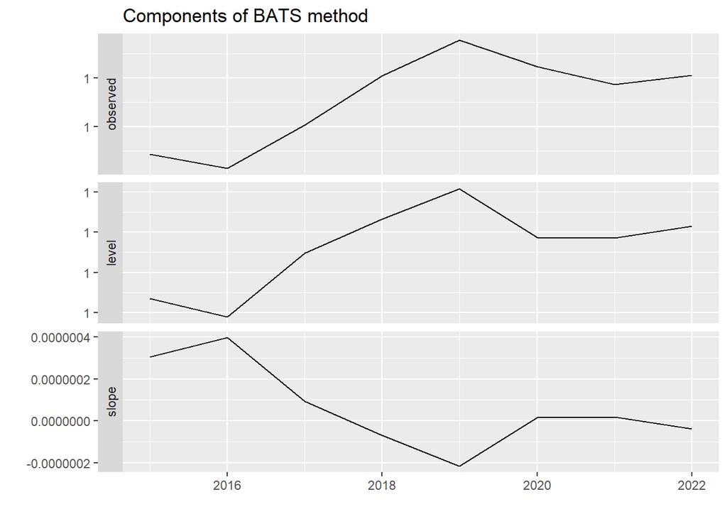

```r
autoplot(fit3.TBATS)
```

```r
summary(fit3.TBATS)
```

```
##                   Length Class  Mode
## lambda             0     -none- NULL
## alpha              1     -none- numeric
## beta               1     -none- numeric
## damping.parameter  1     -none- numeric
## gamma.values       0     -none- NULL
## ar.coefficients    0     -none- NULL
## ma.coefficients    0     -none- NULL
## likelihood         1     -none- numeric
## optim.return.code  1     -none- numeric
## variance           1     -none- numeric
## AIC                1     -none- numeric
## parameters         2     -none- list
## seed.states        2     -none- numeric
## fitted.values      8     ts     numeric
## errors             8     ts     numeric
## x                 16     -none- numeric
## seasonal.periods   0     -none- NULL
## y                  8     ts     numeric
## call               2     -none- call
## series             1     -none- character
## method             1     -none- character
```

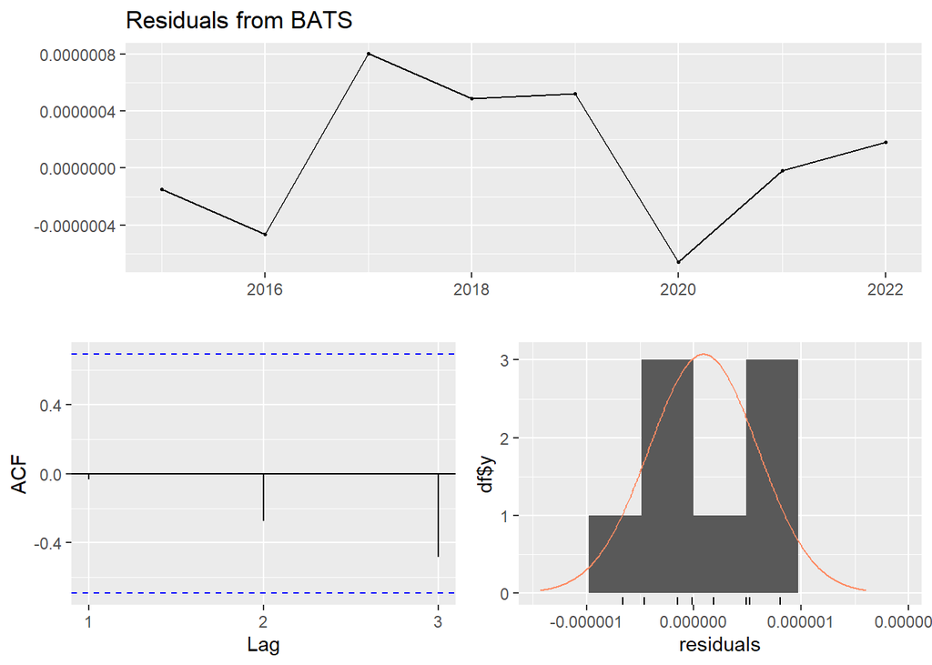

```
##
##  Ljung-Box test
##
## data:  Residuals from BATS
## Q* = 5, df = 3, p-value = 0.2
##
## Model df: 0.   Total lags used: 3
```

```r
checkresiduals(fit3.TBATS)
```

```r
#no good
```

## AC4: Portefeuille-titres commercial et AC5: Portefeuille d’investissement:

- En se basant sur le bilan type (simplifié) de la banque il convient de combiner ces deux variables en une seule qui contient leur somme **AC45**.

[figure not shown]

## AC45

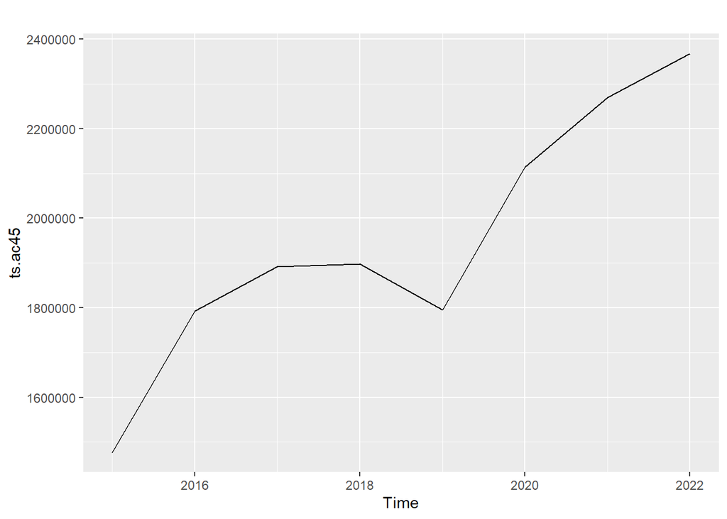

```r
ts.ac45<-ts(rev(b$ac4+b$ac5),start=2015,frequency=1)
autoplot(ts.ac45)
```

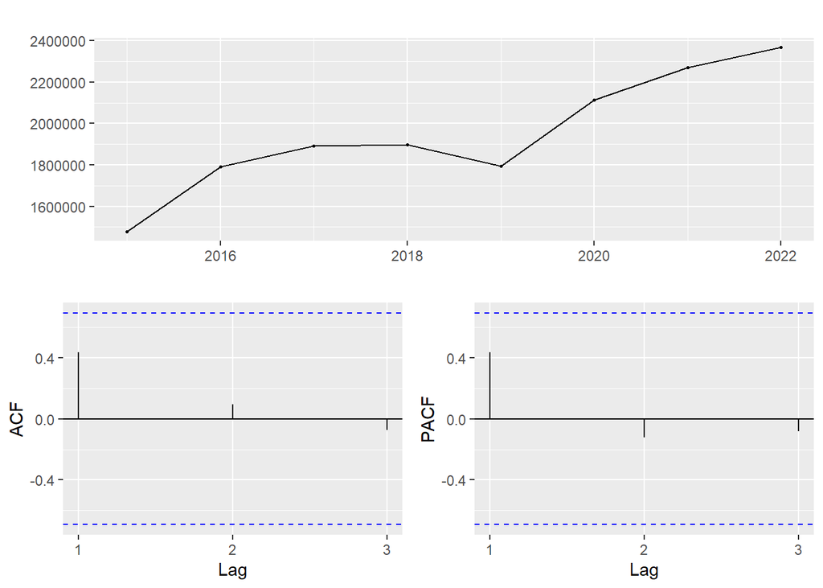

```r
ggtsdisplay(ts.ac45)
```

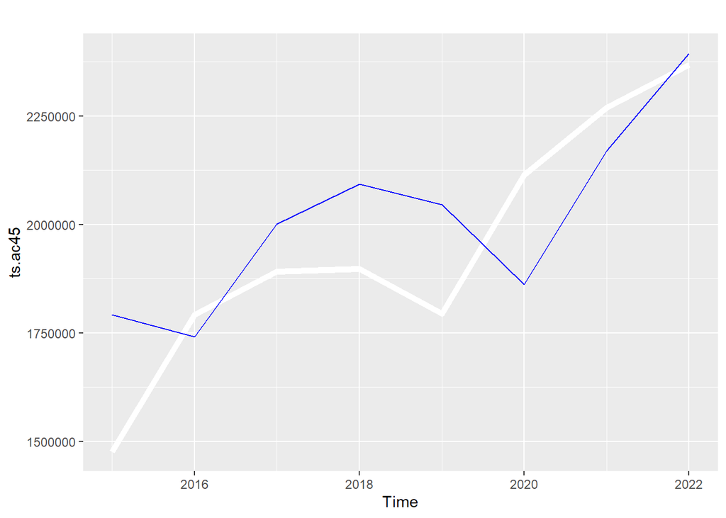

```r
fit45.holt<-holt(ts.ac45)
autoplot(ts.ac45, color = "white", lwd = 2) +
   autolayer(fit45.holt$fitted, color = "blue")
```